# Homework 4

Author: Matthew J. Cossley

Last update: 18 April, 2021

## General instructions

When responding to every question that requires you to perform a hypothesis test, please follow the instructions laid out below.

**1. Specify the null and alternative hypotheses ($H_0$ and $H_1$) in terms of a distribution and population parameter $\theta$.**

You will need to perform this step in order to correctly perform any hypothesis test, but for the homework, just writing it in comments is adequate (your comments won’t be graded). E.g., if asked to test the hypothesis that the true mean of a random variable is greater than 0.5, you might write:

```r
# In this problem, the parameter theta that we are
# interested in is the population mean mu

# H0: mu = 0.5
# H1: mu > 0.5
```

**2. Specify the type I error rate – denoted by the symbol $\alpha$ – you are willing to tolerate.**

For every problem in this homework use $\alpha=0.05$. Again, writing this in comments is adequate (your comments won’t be graded). E.g., you could write:

```r
# set type I error rate
# alpha = 0.05
```

**3. Specify the sample statistic that you will use to estimate the population parameter in step 1 and state how it is distributed under the assumption that $H_0$ is true.**

- A good way to begin is to again write out some comments. To continue with the example from step 1, you might begin by writing:

```r
# theta_hat = mu_hat
# mu_hat = x_bar
# x_bar ~ N(mu_x_bar, sig_x_bar)
# mu_x_bar = mu_x
# sig_x_bar = sig_x

# NOTE: This example assumes sig_x is known.
```

```r
# theta_hat = mu_hat
# mu_hat = x_bar

# x_bar is continuous

# NOTE: You will have to think about whether or not x_bar
# has a finite or infinite range for each particular
# scenario. For this exampl, lets assume it is infinite
# range.

theta_hat_x <- seq(mu_x_bar - 4*sig_x_bar, mu_x_bar + 4*sig_x_bar, 0.01)
```

- Create a variable named `theta_hat_p` and set its value to the probability mass (if discrete) or probability density (if continuous) corresponding to each possible outcome of $\widehat{\theta}$ stored in variable `theta_hat_x`.

```r
# Since theta_hat = x_bar and x_bar is normal, we use dnorm()
# Assuming that you have previously defined  mu_x_bar and
# sig_x_bar, you could write:
theta_hat_p <- dnorm(theta_hat_x, mu_x_bar, sig_x_bar)
```

- Plot the $\widehat{\theta}$ sampling distribution. Put the possible outcomes of $\widehat{\theta}$ on the x-axis and put the probability density or mass (whichever is appropriate) on the y-axis. Use only `ggplot()` and `geom_line()` (if continuous) or `geom_point()` (if discrete). You should use this plot to contextualize the p-value and critical value computed below (i.e., use it to check your work!).

```r
d <- data.table(theta_hat_x, theta_hat_p)
ggplot(d, aes(theta_hat_x, theta_hat_p)) +
   geom_line()
   # geom_line() because in this example theta_har is x_bar is continuous
```

**4. Obtain a random sample and use it to compute the sample statistic from step 3. Call this value $\widehat{\theta}_{\text{obs}}$**

- Create a variable named `theta_hat_obs` and set its value to $\widehat{\theta}_{\text{obs}}$.

```r
# Obtaining the observed value will be matter of wrangling a
# data.table (named dt in the code example below) or maybe
# simply reading the problem carefully. In this example,
# look something like:
x_bar_obs <- dt[, mean(x)]
theta_hat_obs <- x_bar_obs
```

**5. If $\widehat{\theta}_{\text{obs}}$ is very unlikely to occur under the assumption that $H_0$ is true, then reject $H_0$. Otherwise, do not reject $H_0$.**

- Create a variable named `p_val` and set its value to $P(\widehat{\theta}_{\text{obs}} | H_0)$.

```r
# In this example, p_hat_obs is x_bar_obs which comes from a
# Normal so we use pnorm() with lower.tail determined by the
# alternative hypothesis.
p_val <- pnorm(x_bar_obs, mu_x_bar, sig_x_bar, lower.tail=FALSE)
```

- Create a value named `decision` and set its value either to `"reject H0"` or `"fail to reject H0"`.

```r
# Lets assume p_val < 0.05.
# Then we would write:
decision <- 'reject H0'
```

- If performing a one-tailed test, create a variable named `theta_hat_crit` and set its value to the critical value. If performing a 2-tailed test, create two variables, `theta_hat_crit_lower` and `theta_hat_crit_upper` and set their values to the corresponding critical values.

```r
# Our running example is a one-tailed test so we only have
# one critical value. Furthermore, x_bar is normal so we use
# the qnorm() function to get the x_bar outcome that
# corresponds to P(X > x | H0) < 0.05.
theta_hat_crit <- qnorm(0.05, mu_x_bar, sig_x_bar, lower.tail=FALSE)
```

- Calculate the 95% confidence interval estimate of the parameter in step 1. Create a variable named `ci_lower` and set its value to the lower bound of this confidence interval, and create a variable named `ci_upper` and set its value to the upper bound of this confidence interval. Make sure that the decision you reach on the basis of this confidence interval is the same as you reached using the p-value.

```r
# The width of the confidence interval is easy to obtain if
# you remember that it is the same as the width between the
# two critical values if your test was a two-tailed test.
x_bar_crit_lower <- qnorm(0.025, mu_x_bar, sig_x_bar, lower.tail=TRUE)
x_bar_crit_upper <- qnorm(0.025, mu_x_bar, sig_x_bar, lower.tail=FALSE)
x_bar_ci_width <- x_bar_crit_upper - x_bar_crit_lower

# The centre of the confidence interval is just the
# theta_hat_obs, which in this case is x_bar_obs.
x_bar_ci_lower <- x_bar_obs - x_bar_xi_width / 2
x_bar_ci_upper <- x_bar_obs + x_bar_xi_width / 2
```

**6. If there is a built-in R function that will perform the test in question, use and verify that it returns the same results as running through steps 1 through 5 in long form.**

- Create a variable named `r_result` and set its value to the result of the built-in R function. If no built-in function exists, set `r_result <- "does not exist"`.

```r
# In our running example we know sig_x, and so we are
# performing a Normal test. There is no built-in R function
# to perform this test.
r_result <- "does not exist"

# If you did not know sig_x, and you were consequently
# performing a t-test, then you would use code similar to:
x <- dt[, x]
r_result <- t.test(x, mu=0.5, alternative='greater')
```

**7. Create problem-specific variables to store the work form the previous steps to facilitate grading.**

- For a one-tailed test use:

```r
prob_x_theta_hat_x <- theta_hat_x
prob_x_theta_hat_p <- theta_hat_p
prob_x_theta_hat_obs <- theta_hat_obs
prob_x_pval <- p_val
prob_x_theta_hat_crit <- theta_hat_crit
prob_x_ci_lower <- theta_hat_ci_lower
prob_x_ci_upper <- theta_hat_ci_upper
prob_x_decision <- decision
prob_x_r_result <- r_result
```

- For a two-tailed test use:

```r
prob_x_theta_hat_x <- theta_hat_x
prob_x_theta_hat_p <- theta_hat_p
prob_x_theta_hat_obs <- theta_hat_obs
prob_x_pval_lower <- p_val_lower
prob_x_pval_upper <- p_val_upper
prob_x_theta_hat_crit_lower <- theta_hat_crit_lower
prob_x_theta_hat_crit_upper <- theta_hat_crit_upper
prob_x_ci_lower <- theta_hat_ci_lower
prob_x_ci_upper <- theta_hat_ci_upper
prob_x_decision <- decision
prob_x_r_result <- r_result
```

- Be sure to replace the `x` in the `prob_x` above with the problem number.
- **NOTE:** In all cases, but especially when performing t-tests, please think carefully about what $\widehat{\theta}_{\text{obs}}$ is estimating. In particular, be sure that the variable `theta_hat_obs` contains a number that estimates the parameter in step 1.

## Problem 0

- Load `data.table` and `ggplot2` but no other packages.
- Do not call `install.packages` anywhere in this script. Once you installed them once, there is no need to install them again. If you need to install some other package in the future, do so by using `install.packages` function in the console.
- Make sure you are starting with a clean environment by running `rm(list=ls())`. Running this line of code will erase any variable defined before it. Do not put this line of code after anything important to keep for grading.
- Create a variable named `my_name` and set its value equal to a **character** vector (i.e., letters surrounded by `""`) containing your name.
- Create a variable named `my_student_id` and set its value equal to a **character** vector (i.e., letters surrounded by `""`) containing your student id.

## Problem 1

**(a)** load the data located in the csv file linked below into a data.table named `d`.

https://crossley.github.io/cogs2020/data/nhp_cat_learn/ii_gabor.csv

This data file contains the results from a monkey performing a category learning experiment similar to those that we have seen a handful of times already in this class. On each trial of the experiment the monkey sees a sine-wave grating and must learn through trial and error whether that grating is a member of category A or category B.

**(b)** Change the column names to the following

`col_names <- c('cat', 'x', 'y', 'resp', 'rt', 'phase')`

**(c)** Add a column named `trial` to the data.table that indicates the trial of the experiment. Note that `trial` should start at 1 and increment by 1 all the way to the number of total rows in `d`.

**(d)** Add a column named `block` to the `data.table` that indicates the block of the experiment, assuming a block size of 100 trials per block. Note that a block size of 100 does not divide evenly into the number of rows in `d` (i.e., 8196), so you will have to be careful and clever in dealing with this. However you deal with it, the final 96 trials in `d` should correspond to a block value of 82.

**(e)** Add a column named `acc` to the `data.table` that indicates whether the response on each trial was correct or incorrect (e.g., `cat == resp`).

**(f)** Create a new data.table named `dd` that contains columns for the mean accuracy per block (name this column `acc_mean`) and the SEM (name this column `acc_err`) per block, grouped by each unique combination of `block` and `phase`. Please ensure that `dd` contains only `acc_mean`, `acc_err`, `block`, and `phase` columns.

**(g)** Replicate the following plot exactly using only `ggplot()`, `geom_line()` and `geom_pointrange()`. Save resulting ggplot object as a variable named `g`.

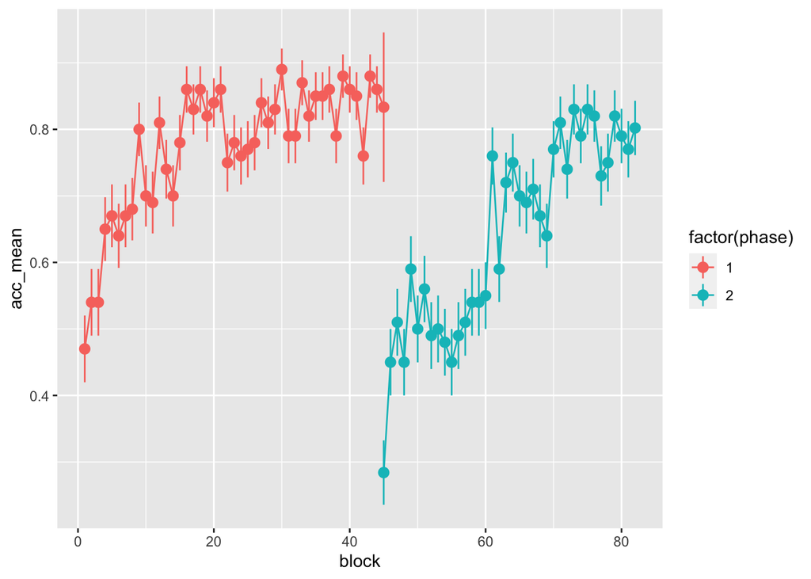

## Problem 2 - 4

In the dataset from Problem 1, each trial is a Bernoulli trial with probability of success $p$. This means that trials are distributed $X \sim Bernoulli(p)$. This also means that blocks of trials are distributed $X \sim Binomial(n,p)$, where $n$ is the block size (i.e., number of trials per block).

**Problem 2.** Test the hypothesis that, for the first 100 trials of phase 1, the monkey is doing no better and no worse than guessing (i.e., $p = .5$).

**Problem 3.** Test the hypothesis that, for the last 100 trials of phase 1, the monkey is doing better than guessing (i.e., $p = .5$). For this problem, only `prob_x_r_result` will be graded.

**Problem 4.** Test the hypothesis that, for the first 100 trials of phase 2, the monkey is doing worse than guessing (i.e., $p = .5$). For this problem, only `prob_x_r_result` will be graded.

## Problem 5-8

Above, we viewed each trial as $Bernoulli(p)$, and each $n$ trials as $Binomial(n,p)$. An alternative framing is to ignore each individual trial, and instead consider the random variable

$X = \text{mean accuracy per block}$

In this framing, the experiment results are sampled from blocks of trials, not from individual trials.

**Problem 5.** Make a deep copy of `d` named `d2`, and then redefine the block column of `d2` to reflect a block size of 25 trials per block instead of 100. Then, using `d2` as a base, create a new data.table named `dd2` that contains columns for the mean accuracy per block (name this column `acc_mean`) and the SEM (name this column `acc_err`) per `block`, grouped by each unique combination of `block` and `phase`. Please ensure that `dd2` contains only `acc_mean`, `acc_sem`, `block`, and `phase` columns. Repeat the mean accuracy plot using the new block size to visually check that your work is doing what you think it’s doing (this plot will not be graded).

Also, when reporting confidence intervals, remember that you are to report an interval estimate of the parameter in step 1. This means that if you are performing a t-test, you will have to be careful when converting between t and X distributions.

**Problem 6.** Test the hypothesis that the mean accuracy in the first 16 blocks of phase 1 is no greater or worse than chance (i.e. 50% correct responses).

**Problem 7.** Test the hypothesis that the mean accuracy in the last 16 blocks of phase 1 is greater than chance. For this problem, only `prob_x_r_result` will be graded.

**Problem 8.** Test the hypothesis that the mean accuracy in the first 16 blocks of phase 2 less than chance. For this problem, only `prob_x_r_result` will be graded.

## Problem 9

What accounts for the drop in accuracy between phase 1 and phase 2? To answer this question, investigate the stimuli the monkey was required to learn between phase 1 and phase 2 by replicating the plot below exactly, and using the data.table `d` as a the plot data. The ggplot function `facet_wrap()` will be helpful to you. Save the resulting plot to a variable named `ans_9`.

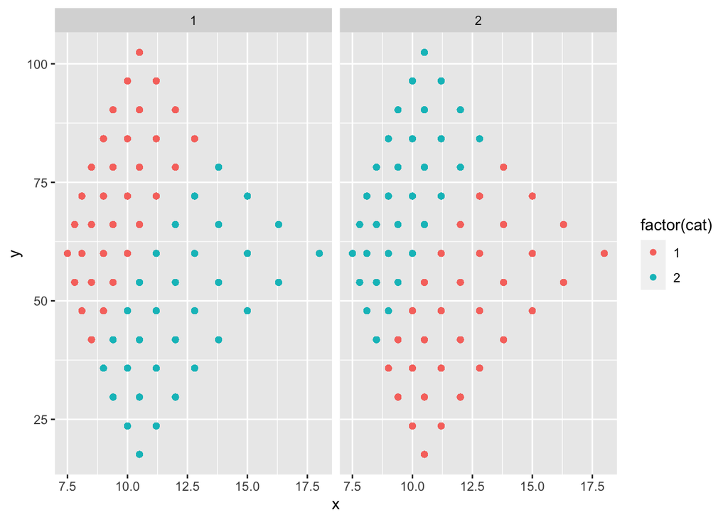

## problem 10

For the first 16 blocks of phase 1, assuming that you are performing a one-tailed test, and assuming that the true state of the universe is $\mu=.6$. Given $H_0:\mu=.5$

- compute $\alpha$ and store its value in a variable named `ans_10a`
- compute $\beta$ and store its value in a variable named `ans_10b`
- compute $power$ and store its value in a variable named `ans_10c`

## Problem 11

The number of action potentials generated from a given neuron in its baseline state when observed for a fixed period of time (1 second) is well described by a Poisson distribution. The Poisson distribution is fully characterised by a single parameter $\lambda$ called the rate parameter. It turns out that $\lambda$ is also the mean of the Poisson distribution. Suppose a group of researchers measured a particular neuron and observed 5 action potentials in a given time period. Let $X$ be the Poisson random variable that generated this result. Test the hypothesis that $\lambda > 4 events per second$. You will need to search the web or use the built-in R help to look or functions that tell you about Poisson probabilities etc. You ought to find an R function that will do the entre test for you, and it would be wise to use this function to check your work, but please perform all 5 steps as indicated in the general instructions at the top of this homework.

## Problem 12

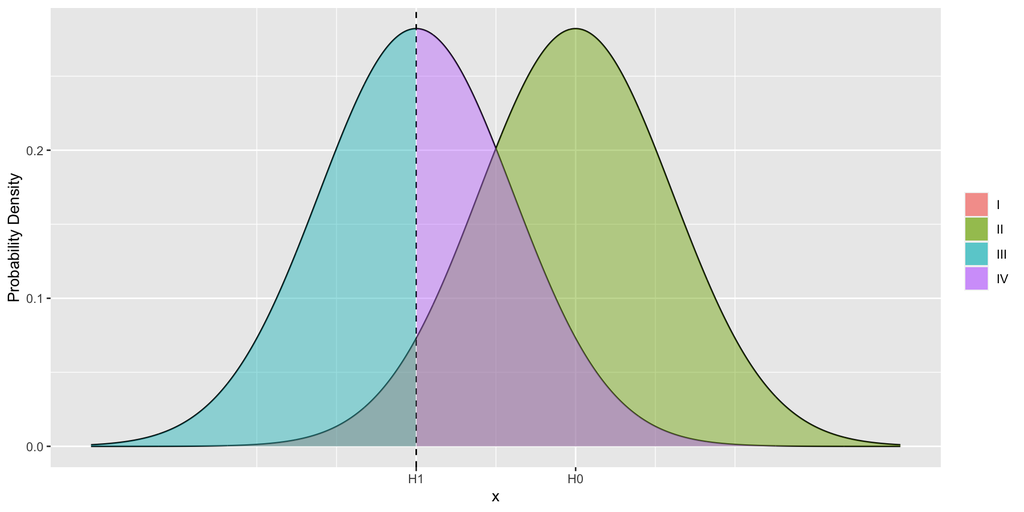

Please respond by assigning `"confidence"`, `"alpha"`, `"beta"`, or `"power"` to the variables requested below. Note that the dashed line in the above figure is the critical value.

- What quantity does region I in the above plot correspond to? Store your answer in a variable named `ans_12a`.
- What quantity does region II in the above plot correspond to? Store your answer in a variable named `ans_12b`.
- What quantity does region III in the above plot correspond to? Store your answer in a variable named `ans_12c`.
- What quantity does region IV in the above plot correspond to? Store your answer in a variable named `ans_12d`.
- What is the numeric value (to two decimal places) of the power in this example? Store your answer in a variable named `ans_12e`.
- Assuming a type I error rate of 0.05, what is the numeric value (to two decimal places) of confidence of this example? Store your answer in a variable named `ans_12f`.
- Assuming that the illustrated distributions correspond to the distribution of sample means, will increasing the sample size increase the distance between the mean of H1 and H0 distributions? Store your answer using `ans_12g <- "YES"` or `ans_12g <- "NO"`.